# Module 2: R4MS - Workshop 1

Author

Katie Dyck

Published

June 3, 2026

# 1 Introduction

This document includes all material covered from the first “R for Marine Science” workshop:

- Importing different file types (`.csv`, `.txt`, `.xlsx`)
- Foundational grammar for slicing, filtering, sorting, and transforming data
- Aggregating and summarizing data
- Visualizing the `penguins` dataset from the `palmerpenguins` package
- How to save and export datasets and plots

# 2 Housekeeping

Purge the global environment with the command `rm(list = ls())`.

# 3 Packages

The `tidyverse`, `readxl`, and `palmerpenguins` package libraries are needed for this workshop.

# 4 Importing different file types

- .csv files can be imported with `read_csv()`.
- .txt files can be imported with `read_tsv()`.
- .xlsx files can be imported with `read_excel()`.

```r
benthic_cover <- read_csv(here::here("data/workshop1/reef_cover_log.csv"))
```

| site_id | transect_no | date | depth_m | hard_coral_pct | macroalgae_pct | bare_substrate_pct |
| --- | --- | --- | --- | --- | --- | --- |
| Nelly_Bay | 1 | 2026-05-10 | 4.5 | 45.2 | 12.1 | 42.7 |
| Nelly_Bay | 2 | 2026-05-10 | 5.1 | 38.5 | 15.4 | 46.1 |
| Geoffrey_Bay | 1 | 2026-05-11 | 3.8 | 52.1 | 8.3 | 39.6 |
| Geoffrey_Bay | 2 | 2026-05-11 | 4.2 | 48.9 | 10.2 | 40.9 |
| Florence_Bay | 1 | 2026-05-12 | 6.0 | 61.3 | 5.1 | 33.6 |
| Florence_Bay | 2 | 2026-05-12 | 5.8 | 58.7 | 6.4 | 34.9 |

```r
acoustic_stream <- read_tsv(here::here("data/workshop1/acoustic_telemetry_stream.txt"))
```

| timestamp | receiver_id | tag_id | species | sensor_depth_m |
| --- | --- | --- | --- | --- |
| 2026-05-01 08:14:22 | REC-01 | TAG-1042 | Carcharhinus_melanopterus | 12.4 |
| 2026-05-01 08:19:45 | REC-01 | TAG-1042 | Carcharhinus_melanopterus | 11.8 |
| 2026-05-01 09:02:11 | REC-02 | TAG-0899 | Chelonia_mydas | 4.2 |
| 2026-05-01 09:15:33 | REC-02 | TAG-0899 | Chelonia_mydas | 2.1 |
| 2026-05-01 10:44:05 | REC-03 | TAG-1042 | Carcharhinus_melanopterus | 18.6 |
| 2026-05-01 11:05:59 | REC-01 | TAG-1120 | Triaenodon_obesus | 14.5 |

```r
fisheries_annual <- read_excel(here::here("data/workshop1/fish_catch_data.xlsx"), sheet = "Commercial_2026")
```

| vessel_id | date | target_species | catch_weight_kg | bycatch_weight_kg | zone |
| --- | --- | --- | --- | --- | --- |
| FV_Reef_Runner | 2026-03-14 | Plectropomus_leopardus | 450.5 | 12.2 | GBR_Central |
| FV_Ocean_Bounty | 2026-03-15 | Plectropomus_leopardus | 380.0 | 18.5 | GBR_Central |
| FV_Coral_Sea | 2026-03-15 | Lethrinus_miniatus | 520.3 | 25.1 | GBR_North |
| FV_Reef_Runner | 2026-03-18 | Plectropomus_leopardus | 410.8 | 9.4 | GBR_Central |
| FV_Wave_Dancer | 2026-03-19 | Lethrinus_miniatus | 605.2 | 33.8 | GBR_South |

```r
mangrove_data <- read_csv(here::here("data/workshop1/mangrove_survey_raw.csv"))
```

| Field team: Smith and Jones |
| --- |
| Location: Hinchinbrook Island Transect Alpha |
| Weather: Overcast, light rain, tide incoming |
| Equipment: 50m tape, 1x1m quadrats, refractometer |
| NOTE: Equipment failure on plot 3 (refractometer dropped), depth recorded as ND and salinity as 9999. |
| site_id,plot_no,canopy_height_m,crab_burrows_count,salinity_ppt,notes |
| HIN_A,1,4.2,12,35.5,Normal |
| HIN_A,2,3.8,.,34.8,Crab count missed |
| HIN_A,3,4.5,15,9999,Equipment failure |
| HIN_B,1,NA,8,36.1,Canopy too dense to measure |
| HIN_B,2,5.1,0,ND,Water depth too high for reading |

[output cut: 1 more lines]

For the mangrove data, we need to include additional arguments so that the first 5 lines of the dataset are ignored. These lines are just comments that are not part of the data.

```r
# Use args in read_csv() to read mangrove_data properly
mangrove_data <- read_csv(here::here("data/workshop1/mangrove_survey_raw.csv"),
                          skip = 5,       # skip the first 5 lines of field notes
                          na = c(".", "NA", "9999", "ND", "blank"))      # convert known text alternatives to true NA
mangrove_data
```

| site_id | plot_no | canopy_height_m | crab_burrows_count | salinity_ppt | notes |
| --- | --- | --- | --- | --- | --- |
| HIN_A | 1 | 4.2 | 12 | 35.5 | Normal |
| HIN_A | 2 | 3.8 | NA | 34.8 | Crab count missed |
| HIN_A | 3 | 4.5 | 15 | NA | Equipment failure |
| HIN_B | 1 | NA | 8 | 36.1 | Canopy too dense to measure |
| HIN_B | 2 | 5.1 | 0 | NA | Water depth too high for reading |
| HIN_B | 3 | 4.9 | NA | 35.2 | Data sheet smudged |

All 4 data sets are tibbles. You can turn tibbles, which are `tidyverse` data objects, into a data frame:

```r
benthic_cover_df <- as.data.frame(benthic_cover)

benthic_cover
```

| site_id | transect_no | date | depth_m | hard_coral_pct | macroalgae_pct | bare_substrate_pct |
| --- | --- | --- | --- | --- | --- | --- |
| Nelly_Bay | 1 | 2026-05-10 | 4.5 | 45.2 | 12.1 | 42.7 |
| Nelly_Bay | 2 | 2026-05-10 | 5.1 | 38.5 | 15.4 | 46.1 |
| Geoffrey_Bay | 1 | 2026-05-11 | 3.8 | 52.1 | 8.3 | 39.6 |
| Geoffrey_Bay | 2 | 2026-05-11 | 4.2 | 48.9 | 10.2 | 40.9 |
| Florence_Bay | 1 | 2026-05-12 | 6.0 | 61.3 | 5.1 | 33.6 |
| Florence_Bay | 2 | 2026-05-12 | 5.8 | 58.7 | 6.4 | 34.9 |

```r
benthic_cover_df
```

| site_id | transect_no | date | depth_m | hard_coral_pct | macroalgae_pct | bare_substrate_pct |
| --- | --- | --- | --- | --- | --- | --- |
| Nelly_Bay | 1 | 2026-05-10 | 4.5 | 45.2 | 12.1 | 42.7 |
| Nelly_Bay | 2 | 2026-05-10 | 5.1 | 38.5 | 15.4 | 46.1 |
| Geoffrey_Bay | 1 | 2026-05-11 | 3.8 | 52.1 | 8.3 | 39.6 |
| Geoffrey_Bay | 2 | 2026-05-11 | 4.2 | 48.9 | 10.2 | 40.9 |
| Florence_Bay | 1 | 2026-05-12 | 6.0 | 61.3 | 5.1 | 33.6 |
| Florence_Bay | 2 | 2026-05-12 | 5.8 | 58.7 | 6.4 | 34.9 |

Notice the difference between these two data sets. `benthic_cover` tells you its dimensions and variable types (character, double, etc.) below the column headers.

## 4.1 Palmer Penguins dataset

The `penguins` dataset from the `palmerpenguins` package library contains measurements of penguin species found near Palmer Station in Antarctica.

```r
# Load package data into active memory
data("penguins")

# Examine dataset structure
glimpse(penguins)       # tidyverse version
```

```
Rows: 344
Columns: 8
$ species           <fct> Adelie, Adelie, Adelie, Adelie, Adelie, Adelie, Adel…
$ island            <fct> Torgersen, Torgersen, Torgersen, Torgersen, Torgerse…
$ bill_length_mm    <dbl> 39.1, 39.5, 40.3, NA, 36.7, 39.3, 38.9, 39.2, 34.1, …
$ bill_depth_mm     <dbl> 18.7, 17.4, 18.0, NA, 19.3, 20.6, 17.8, 19.6, 18.1, …
$ flipper_length_mm <int> 181, 186, 195, NA, 193, 190, 181, 195, 193, 190, 186…
$ body_mass_g       <int> 3750, 3800, 3250, NA, 3450, 3650, 3625, 4675, 3475, …
$ sex               <fct> male, female, female, NA, female, male, female, male…
$ year              <int> 2007, 2007, 2007, 2007, 2007, 2007, 2007, 2007, 2007…
```

```r
# Generate an exploratory summary matrix
summary(penguins)
```

```
      species          island    bill_length_mm  bill_depth_mm
 Adelie   :152   Biscoe   :168   Min.   :32.10   Min.   :13.10
 Chinstrap: 68   Dream    :124   1st Qu.:39.23   1st Qu.:15.60
 Gentoo   :124   Torgersen: 52   Median :44.45   Median :17.30
                                 Mean   :43.92   Mean   :17.15
                                 3rd Qu.:48.50   3rd Qu.:18.70
                                 Max.   :59.60   Max.   :21.50
                                 NA's   :2       NA's   :2
 flipper_length_mm  body_mass_g       sex           year
 Min.   :172.0     Min.   :2700   female:165   Min.   :2007
 1st Qu.:190.0     1st Qu.:3550   male  :168   1st Qu.:2007
 Median :197.0     Median :4050   NA's  : 11   Median :2008
 Mean   :200.9     Mean   :4202                Mean   :2008
 3rd Qu.:213.0     3rd Qu.:4750                3rd Qu.:2009
 Max.   :231.0     Max.   :6300                Max.   :2009
 NA's   :2         NA's   :2
```

- Note that the `bill_length_mm`, `bill_depth_mm`, `flipper_length_mm`, `body_mass_g`, and `sex` variables have some NA values.

# 5 Foundational grammar: Slicing, filtering, sorting, and transforming

## 5.1 `select()`

This verb allows you to vertically slice datasets, isolating specific columns by variable names.

```r
# Vertically slice specific variables by name
morphology_metrics <- select(penguins, species, bill_length_mm, bill_depth_mm, body_mass_g)
morphology_metrics
```

| species | bill_length_mm | bill_depth_mm | body_mass_g |
| --- | --- | --- | --- |
| Adelie | 39.1 | 18.7 | 3750 |
| Adelie | 39.5 | 17.4 | 3800 |
| Adelie | 40.3 | 18.0 | 3250 |
| Adelie | NA | NA | NA |
| Adelie | 36.7 | 19.3 | 3450 |
| Adelie | 39.3 | 20.6 | 3650 |
| Adelie | 38.9 | 17.8 | 3625 |
| Adelie | 39.2 | 19.6 | 4675 |
| Adelie | 34.1 | 18.1 | 3475 |
| Adelie | 42.0 | 20.2 | 4250 |

[output cut: 334 more lines]

```r
# Retain a continuous block of attributes using colon operator
spatial_block <- select(penguins, species:island)
spatial_block
```

| species | island |
| --- | --- |
| Adelie | Torgersen |
| Adelie | Torgersen |
| Adelie | Torgersen |
| Adelie | Torgersen |
| Adelie | Torgersen |
| Adelie | Torgersen |
| Adelie | Torgersen |
| Adelie | Torgersen |
| Adelie | Torgersen |
| Adelie | Torgersen |

[output cut: 334 more lines]

```r
# Discard logistics tracking attributes while keeping everything else using minus sign
clean_scientific_fields <- select(penguins, -year)
clean_scientific_fields
```

| species | island | bill_length_mm | bill_depth_mm | flipper_length_mm | body_mass_g | sex |
| --- | --- | --- | --- | --- | --- | --- |
| Adelie | Torgersen | 39.1 | 18.7 | 181 | 3750 | male |
| Adelie | Torgersen | 39.5 | 17.4 | 186 | 3800 | female |
| Adelie | Torgersen | 40.3 | 18.0 | 195 | 3250 | female |
| Adelie | Torgersen | NA | NA | NA | NA | NA |
| Adelie | Torgersen | 36.7 | 19.3 | 193 | 3450 | female |
| Adelie | Torgersen | 39.3 | 20.6 | 190 | 3650 | male |
| Adelie | Torgersen | 38.9 | 17.8 | 181 | 3625 | female |
| Adelie | Torgersen | 39.2 | 19.6 | 195 | 4675 | male |
| Adelie | Torgersen | 34.1 | 18.1 | 193 | 3475 | NA |
| Adelie | Torgersen | 42.0 | 20.2 | 190 | 4250 | NA |

[output cut: 334 more lines]

## 5.2 `filter()`

This verb isolates records (rows) horizontally based on conditional parameters. R evaluates each row against a logical expression, keeping entries that are true and dropping those that are false or NA (i.e. those that do not meet the conditions of the expression).

```r
# Isolate observations belonging to a single categorical target group
adelie_cohort <- filter(penguins, species == "Adelie")
adelie_cohort
```

| species | island | bill_length_mm | bill_depth_mm | flipper_length_mm | body_mass_g | sex | year |
| --- | --- | --- | --- | --- | --- | --- | --- |
| Adelie | Torgersen | 39.1 | 18.7 | 181 | 3750 | male | 2007 |
| Adelie | Torgersen | 39.5 | 17.4 | 186 | 3800 | female | 2007 |
| Adelie | Torgersen | 40.3 | 18.0 | 195 | 3250 | female | 2007 |
| Adelie | Torgersen | NA | NA | NA | NA | NA | 2007 |
| Adelie | Torgersen | 36.7 | 19.3 | 193 | 3450 | female | 2007 |
| Adelie | Torgersen | 39.3 | 20.6 | 190 | 3650 | male | 2007 |
| Adelie | Torgersen | 38.9 | 17.8 | 181 | 3625 | female | 2007 |
| Adelie | Torgersen | 39.2 | 19.6 | 195 | 4675 | male | 2007 |
| Adelie | Torgersen | 34.1 | 18.1 | 193 | 3475 | NA | 2007 |
| Adelie | Torgersen | 42.0 | 20.2 | 190 | 4250 | NA | 2007 |

[output cut: 142 more lines]

```r
# Filter out individuals using continuous numerical boundary thresholds
# Keeps only large penguins whose mass exceeds 4500 g
heavy_penguins <- filter(penguins, body_mass_g > 4500)
heavy_penguins
```

| species | island | bill_length_mm | bill_depth_mm | flipper_length_mm | body_mass_g | sex | year |
| --- | --- | --- | --- | --- | --- | --- | --- |
| Adelie | Torgersen | 39.2 | 19.6 | 195 | 4675 | male | 2007 |
| Adelie | Dream | 39.8 | 19.1 | 184 | 4650 | male | 2007 |
| Adelie | Dream | 39.6 | 18.8 | 190 | 4600 | male | 2007 |
| Adelie | Torgersen | 42.9 | 17.6 | 196 | 4700 | male | 2008 |
| Adelie | Biscoe | 41.0 | 20.0 | 203 | 4725 | male | 2009 |
| Adelie | Biscoe | 43.2 | 19.0 | 197 | 4775 | male | 2009 |
| Adelie | Biscoe | 45.6 | 20.3 | 191 | 4600 | male | 2009 |
| Gentoo | Biscoe | 50.0 | 16.3 | 230 | 5700 | male | 2007 |
| Gentoo | Biscoe | 50.0 | 15.2 | 218 | 5700 | male | 2007 |
| Gentoo | Biscoe | 47.6 | 14.5 | 215 | 5400 | male | 2007 |

[output cut: 105 more lines]

```r
# Combine multiple conditional parameters across separate attributes
# Keep records that match Gentoo penguins sampled explicitly on Biscoe Island
biscoe_gentoo <- filter(penguins, species == "Gentoo" & island == "Biscoe")
biscoe_gentoo
```

| species | island | bill_length_mm | bill_depth_mm | flipper_length_mm | body_mass_g | sex | year |
| --- | --- | --- | --- | --- | --- | --- | --- |
| Gentoo | Biscoe | 46.1 | 13.2 | 211 | 4500 | female | 2007 |
| Gentoo | Biscoe | 50.0 | 16.3 | 230 | 5700 | male | 2007 |
| Gentoo | Biscoe | 48.7 | 14.1 | 210 | 4450 | female | 2007 |
| Gentoo | Biscoe | 50.0 | 15.2 | 218 | 5700 | male | 2007 |
| Gentoo | Biscoe | 47.6 | 14.5 | 215 | 5400 | male | 2007 |
| Gentoo | Biscoe | 46.5 | 13.5 | 210 | 4550 | female | 2007 |
| Gentoo | Biscoe | 45.4 | 14.6 | 211 | 4800 | female | 2007 |
| Gentoo | Biscoe | 46.7 | 15.3 | 219 | 5200 | male | 2007 |
| Gentoo | Biscoe | 43.3 | 13.4 | 209 | 4400 | female | 2007 |
| Gentoo | Biscoe | 46.8 | 15.4 | 215 | 5150 | male | 2007 |

[output cut: 114 more lines]

```r
# Search for rows matching multiple targeting flags within an explicit set
sub_islands <- filter(penguins, island %in% c("Dream", "Torgersen"))
sub_islands
```

| species | island | bill_length_mm | bill_depth_mm | flipper_length_mm | body_mass_g | sex | year |
| --- | --- | --- | --- | --- | --- | --- | --- |
| Adelie | Torgersen | 39.1 | 18.7 | 181 | 3750 | male | 2007 |
| Adelie | Torgersen | 39.5 | 17.4 | 186 | 3800 | female | 2007 |
| Adelie | Torgersen | 40.3 | 18.0 | 195 | 3250 | female | 2007 |
| Adelie | Torgersen | NA | NA | NA | NA | NA | 2007 |
| Adelie | Torgersen | 36.7 | 19.3 | 193 | 3450 | female | 2007 |
| Adelie | Torgersen | 39.3 | 20.6 | 190 | 3650 | male | 2007 |
| Adelie | Torgersen | 38.9 | 17.8 | 181 | 3625 | female | 2007 |
| Adelie | Torgersen | 39.2 | 19.6 | 195 | 4675 | male | 2007 |
| Adelie | Torgersen | 34.1 | 18.1 | 193 | 3475 | NA | 2007 |
| Adelie | Torgersen | 42.0 | 20.2 | 190 | 4250 | NA | 2007 |

[output cut: 166 more lines]

## 5.3 `arrange()`

This verb alters how the rows of data are sorted within your data frame, without changing individual cell values

```r
# Sort penguins by ascending body mass (Default setting: smallest mass first)
lightest_first <- arrange(penguins, body_mass_g)
lightest_first
```

| species | island | bill_length_mm | bill_depth_mm | flipper_length_mm | body_mass_g | sex | year |
| --- | --- | --- | --- | --- | --- | --- | --- |
| Chinstrap | Dream | 46.9 | 16.6 | 192 | 2700 | female | 2008 |
| Adelie | Biscoe | 36.5 | 16.6 | 181 | 2850 | female | 2008 |
| Adelie | Biscoe | 36.4 | 17.1 | 184 | 2850 | female | 2008 |
| Adelie | Biscoe | 34.5 | 18.1 | 187 | 2900 | female | 2008 |
| Adelie | Dream | 33.1 | 16.1 | 178 | 2900 | female | 2008 |
| Adelie | Torgersen | 38.6 | 17.0 | 188 | 2900 | female | 2009 |
| Chinstrap | Dream | 43.2 | 16.6 | 187 | 2900 | female | 2007 |
| Adelie | Biscoe | 37.9 | 18.6 | 193 | 2925 | female | 2009 |
| Adelie | Dream | 37.5 | 18.9 | 179 | 2975 | NA | 2007 |
| Adelie | Dream | 37.0 | 16.9 | 185 | 3000 | female | 2007 |

[output cut: 334 more lines]

```r
# Sort penguins in descending sequence using the desc() layout wrapper
heaviest_first <- arrange(penguins, desc(body_mass_g))
heaviest_first
```

| species | island | bill_length_mm | bill_depth_mm | flipper_length_mm | body_mass_g | sex | year |
| --- | --- | --- | --- | --- | --- | --- | --- |
| Gentoo | Biscoe | 49.2 | 15.2 | 221 | 6300 | male | 2007 |
| Gentoo | Biscoe | 59.6 | 17.0 | 230 | 6050 | male | 2007 |
| Gentoo | Biscoe | 51.1 | 16.3 | 220 | 6000 | male | 2008 |
| Gentoo | Biscoe | 48.8 | 16.2 | 222 | 6000 | male | 2009 |
| Gentoo | Biscoe | 45.2 | 16.4 | 223 | 5950 | male | 2008 |
| Gentoo | Biscoe | 49.8 | 15.9 | 229 | 5950 | male | 2009 |
| Gentoo | Biscoe | 48.4 | 14.6 | 213 | 5850 | male | 2007 |
| Gentoo | Biscoe | 49.3 | 15.7 | 217 | 5850 | male | 2007 |
| Gentoo | Biscoe | 55.1 | 16.0 | 230 | 5850 | male | 2009 |
| Gentoo | Biscoe | 49.5 | 16.2 | 229 | 5800 | male | 2008 |

[output cut: 334 more lines]

```r
# Execute nested sorting criteria: group by species, then sort by descending bill length
stratified_morphology <- arrange(penguins, species, desc(bill_length_mm))
stratified_morphology
```

| species | island | bill_length_mm | bill_depth_mm | flipper_length_mm | body_mass_g | sex | year |
| --- | --- | --- | --- | --- | --- | --- | --- |
| Adelie | Torgersen | 46.0 | 21.5 | 194 | 4200 | male | 2007 |
| Adelie | Torgersen | 45.8 | 18.9 | 197 | 4150 | male | 2008 |
| Adelie | Biscoe | 45.6 | 20.3 | 191 | 4600 | male | 2009 |
| Adelie | Dream | 44.1 | 19.7 | 196 | 4400 | male | 2007 |
| Adelie | Torgersen | 44.1 | 18.0 | 210 | 4000 | male | 2009 |
| Adelie | Dream | 43.2 | 18.5 | 192 | 4100 | male | 2008 |
| Adelie | Biscoe | 43.2 | 19.0 | 197 | 4775 | male | 2009 |
| Adelie | Torgersen | 43.1 | 19.2 | 197 | 3500 | male | 2009 |
| Adelie | Torgersen | 42.9 | 17.6 | 196 | 4700 | male | 2008 |
| Adelie | Torgersen | 42.8 | 18.5 | 195 | 4250 | male | 2008 |

[output cut: 334 more lines]

## 5.4 Pipe operator (`|>`)

The pipe operator is a great way to chain multiple operations together. You read from left to right, or top to bottom. You take the data, *then* filter it, *then* mutate it to create a new column, *then* select the columns you need.

The native R pipe syntax is `|>`, but there is another version built into the tidyverse with the `magrittr` package, which is also commonly used (`%>%`).

Instead of writing:

```r
penguins_subset <- mutate(penguins, bill_ratio = bill_length_mm / bill_depth_mm)
penguins_final <- filter(penguins_subset, species == "Adelie")
```

You can just write:

```r
penguins_final <- penguins |>
    mutate(bill_ratio = bill_length_mm / bill_depth_mm) |>
    filter(species == "Adelie")

penguins_final
```

| species | island | bill_length_mm | bill_depth_mm | flipper_length_mm | body_mass_g | sex | year | bill_ratio |
| --- | --- | --- | --- | --- | --- | --- | --- | --- |
| Adelie | Torgersen | 39.1 | 18.7 | 181 | 3750 | male | 2007 | 2.090909 |
| Adelie | Torgersen | 39.5 | 17.4 | 186 | 3800 | female | 2007 | 2.270115 |
| Adelie | Torgersen | 40.3 | 18.0 | 195 | 3250 | female | 2007 | 2.238889 |
| Adelie | Torgersen | NA | NA | NA | NA | NA | 2007 | NA |
| Adelie | Torgersen | 36.7 | 19.3 | 193 | 3450 | female | 2007 | 1.901554 |
| Adelie | Torgersen | 39.3 | 20.6 | 190 | 3650 | male | 2007 | 1.907767 |
| Adelie | Torgersen | 38.9 | 17.8 | 181 | 3625 | female | 2007 | 2.185393 |
| Adelie | Torgersen | 39.2 | 19.6 | 195 | 4675 | male | 2007 | 2.000000 |
| Adelie | Torgersen | 34.1 | 18.1 | 193 | 3475 | NA | 2007 | 1.883978 |
| Adelie | Torgersen | 42.0 | 20.2 | 190 | 4250 | NA | 2007 | 2.079208 |

[output cut: 142 more lines]

## 5.5 `mutate()`

This verb is used to calculate new variables based on ones that already exist in your data.

```r
penguin_ratios <- penguins |>
    mutate(body_mass_kg = body_mass_g / 1000,
           bill_ratio = bill_length_mm / bill_depth_mm)

penguin_ratios
```

| species | island | bill_length_mm | bill_depth_mm | flipper_length_mm | body_mass_g | sex | year | body_mass_kg | bill_ratio |
| --- | --- | --- | --- | --- | --- | --- | --- | --- | --- |
| Adelie | Torgersen | 39.1 | 18.7 | 181 | 3750 | male | 2007 | 3.750 | 2.090909 |
| Adelie | Torgersen | 39.5 | 17.4 | 186 | 3800 | female | 2007 | 3.800 | 2.270115 |
| Adelie | Torgersen | 40.3 | 18.0 | 195 | 3250 | female | 2007 | 3.250 | 2.238889 |
| Adelie | Torgersen | NA | NA | NA | NA | NA | 2007 | NA | NA |
| Adelie | Torgersen | 36.7 | 19.3 | 193 | 3450 | female | 2007 | 3.450 | 1.901554 |
| Adelie | Torgersen | 39.3 | 20.6 | 190 | 3650 | male | 2007 | 3.650 | 1.907767 |
| Adelie | Torgersen | 38.9 | 17.8 | 181 | 3625 | female | 2007 | 3.625 | 2.185393 |
| Adelie | Torgersen | 39.2 | 19.6 | 195 | 4675 | male | 2007 | 4.675 | 2.000000 |
| Adelie | Torgersen | 34.1 | 18.1 | 193 | 3475 | NA | 2007 | 3.475 | 1.883978 |
| Adelie | Torgersen | 42.0 | 20.2 | 190 | 4250 | NA | 2007 | 4.250 | 2.079208 |

[output cut: 334 more lines]

# 6 Data aggregation & ecological summarization

```r
# Grouping our active memory penguins by species
grouped_penguins <- group_by(penguins, species)

# Note that table looks similar, but metadata notes 'Groups: species [3]'
grouped_penguins
```

| species | island | bill_length_mm | bill_depth_mm | flipper_length_mm | body_mass_g | sex | year |
| --- | --- | --- | --- | --- | --- | --- | --- |
| Adelie | Torgersen | 39.1 | 18.7 | 181 | 3750 | male | 2007 |
| Adelie | Torgersen | 39.5 | 17.4 | 186 | 3800 | female | 2007 |
| Adelie | Torgersen | 40.3 | 18.0 | 195 | 3250 | female | 2007 |
| Adelie | Torgersen | NA | NA | NA | NA | NA | 2007 |
| Adelie | Torgersen | 36.7 | 19.3 | 193 | 3450 | female | 2007 |
| Adelie | Torgersen | 39.3 | 20.6 | 190 | 3650 | male | 2007 |
| Adelie | Torgersen | 38.9 | 17.8 | 181 | 3625 | female | 2007 |
| Adelie | Torgersen | 39.2 | 19.6 | 195 | 4675 | male | 2007 |
| Adelie | Torgersen | 34.1 | 18.1 | 193 | 3475 | NA | 2007 |
| Adelie | Torgersen | 42.0 | 20.2 | 190 | 4250 | NA | 2007 |

[output cut: 334 more lines]

```r
# Collapsing groups into explicit summary metrics
species_mass_summary <- summarise(grouped_penguins,
                                  mean_mass_g = mean(body_mass_g))
species_mass_summary
```

| species | mean_mass_g |
| --- | --- |
| Adelie | NA |
| Chinstrap | 3733.088 |
| Gentoo | NA |

Adelie and Gentoo species data includes NA values - this is an R design feature called the **Missing Value Trap**. Any mathematical function of any kind (sum, mean, sd, etc.) will automatically return NA to prevent miscalculations. This can be overridden by explicitly declaring that missing cells should be dropped during calculations.

```r
biological_signal <- penguins |>
    group_by(species, sex) |>
    summarise(
        sample_size = n(),    # count total number of individuals per category
        mean_mass_g = mean(body_mass_g, na.rm = TRUE),
        sd_mass_g = sd(body_mass_g, na.rm = TRUE)       # standard deviation calculation
    )

biological_signal
```

| species | sex | sample_size | mean_mass_g | sd_mass_g |
| --- | --- | --- | --- | --- |
| Adelie | female | 73 | 3368.836 | 269.3801 |
| Adelie | male | 73 | 4043.493 | 346.8116 |
| Adelie | NA | 6 | 3540.000 | 477.1661 |
| Chinstrap | female | 34 | 3527.206 | 285.3339 |
| Chinstrap | male | 34 | 3938.971 | 362.1376 |
| Gentoo | female | 58 | 4679.741 | 281.5783 |
| Gentoo | male | 61 | 5484.836 | 313.1586 |
| Gentoo | NA | 5 | 4587.500 | 338.1937 |

# 7 Visualizing the `penguins` data

## 7.1 Visualizing body size and shape

```r
penguin_mass_by_island <- penguins |>
    group_by(species, island) |>
    summarise(mean_mass_g = mean(body_mass_g, na.rm = TRUE))

penguin_mass_by_island
```

| species | island | mean_mass_g |
| --- | --- | --- |
| Adelie | Biscoe | 3709.659 |
| Adelie | Dream | 3688.393 |
| Adelie | Torgersen | 3706.373 |
| Chinstrap | Dream | 3733.088 |
| Gentoo | Biscoe | 5076.016 |

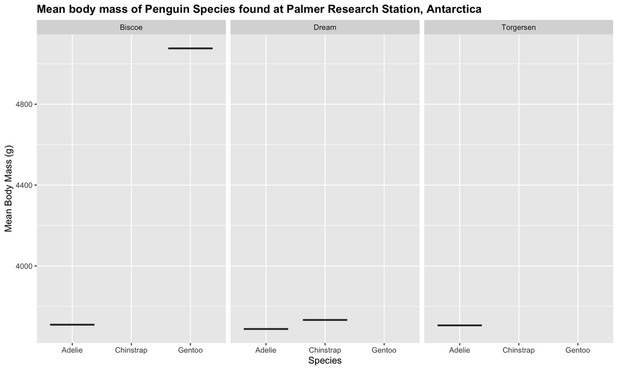

```r
# Visualize the data
ggplot(penguin_mass_by_island, aes(x = species, y = mean_mass_g)) +
    geom_boxplot() +
    facet_wrap(~ island) +
    labs(x = "Species", y = "Mean Body Mass (g)", title = "Mean body mass of Penguin Species found at Palmer Research Station, Antarctica") +
    theme(plot.title = element_text(face = "bold"))
```

You can also pipe directly to visualization without creating an intermediate summary table:

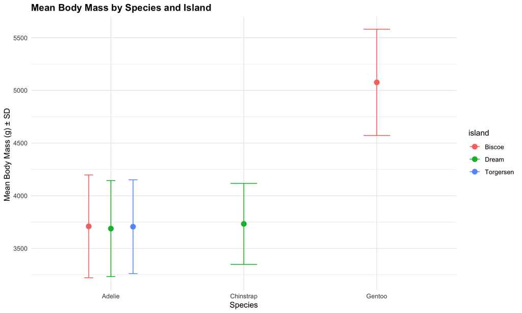

```r
mass_compare_plot <- penguins |>
    filter(!is.na(body_mass_g)) |>    # remove any NA values from body_mass_g
    group_by(species, island) |>
    summarize(
        mean_mass = mean(body_mass_g, na.rm = TRUE),
        n = n(),
        sd_mass = sd(body_mass_g, na.rm = TRUE),
        .groups = "drop"
    ) |>
    ggplot(aes(x = species, y = mean_mass, colour = island)) +
    geom_point(size = 3, position = position_dodge(width = 0.5)) +
    geom_errorbar(aes(ymin = mean_mass - sd_mass,
                      ymax = mean_mass + sd_mass),
                  width = 0.2,
                  position = position_dodge(width = 0.5)) +
    labs(title = "Mean Body Mass by Species and Island",
         x = "Species",
         y = "Mean Body Mass (g) ± SD ") +
    theme_minimal() +
    theme(plot.title = element_text(face = "bold"))

mass_compare_plot
```

## 7.2 **Completed morphological plot and summary table**

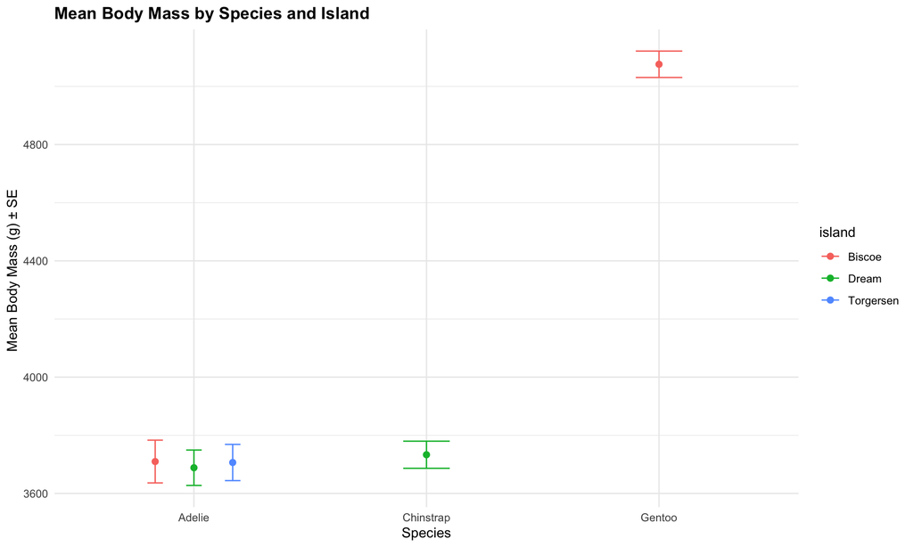

```r
mass_compare_plot2 <- penguins |>
    filter(!is.na(body_mass_g)) |>    # remove any NA values from body_mass_g
    group_by(species, island) |>
    summarize(
        mean_mass = mean(body_mass_g, na.rm = TRUE),
        n = n(),
        sd_mass = sd(body_mass_g, na.rm = TRUE),
        se_mass = sd_mass / sqrt(n),
        .groups = "drop"
    ) |>
    ggplot(aes(x = species, y = mean_mass, colour = island)) +
    geom_point(size = 2, position = position_dodge(width = 0.5)) +
    geom_errorbar(aes(ymin = mean_mass - se_mass,
                      ymax = mean_mass + se_mass),
                  width = 0.2,
                  position = position_dodge(width = 0.5)) +
    labs(title = "Mean Body Mass by Species and Island",
         x = "Species",
         y = "Mean Body Mass (g) ± SE ") +
    theme_minimal() +
    theme(plot.title = element_text(face = "bold"))

mass_compare_plot2
```

When we compare the error bar graphs side-by-side, we see that the standard *error* bars are much smaller than the standard *deviation* bars, which makes sense. Standard error is a measure of how precisely we have estimated the mean, while standard deviation is a measure of how much variability there is in the data. The standard error will always be smaller than the standard deviation, especially as the sample size increases.

```r
summary_SD <- penguins |>
    filter(!is.na(body_mass_g)) |>    # remove any NA values from body_mass_g
    group_by(species, island) |>
    summarize(
        mean_mass = mean(body_mass_g, na.rm = TRUE),
        n = n(),
        sd_mass = sd(body_mass_g, na.rm = TRUE),
        .groups = "drop"
    )

summary_SE <- penguins |>
    filter(!is.na(body_mass_g)) |>    # remove any NA values from body_mass_g
    group_by(species, island) |>
    summarize(
        mean_mass = mean(body_mass_g, na.rm = TRUE),
        n = n(),
        sd_mass = sd(body_mass_g, na.rm = TRUE),
        se_mass = sd_mass / sqrt(n),
        .groups = "drop"
    )

summary_SE
```

| species | island | mean_mass | n | sd_mass | se_mass |
| --- | --- | --- | --- | --- | --- |
| Adelie | Biscoe | 3709.659 | 44 | 487.7337 | 73.52863 |
| Adelie | Dream | 3688.393 | 56 | 455.1464 | 60.82150 |
| Adelie | Torgersen | 3706.373 | 51 | 445.1079 | 62.32758 |
| Chinstrap | Dream | 3733.088 | 68 | 384.3351 | 46.60747 |
| Gentoo | Biscoe | 5076.016 | 123 | 504.1162 | 45.45463 |

# 8 Saving, exporting, and version milestones

We can save our figures and tables to our GitHub repository by creating an “output” folder in our directory.

```r
# Create output directories if they do not exist:
if (!dir.exists("outputs/figures")) dir.create("outputs/figures", recursive = TRUE)   # folder for figs
if (!dir.exists("outputs/tables")) dir.create("outputs/tables", recursive = TRUE)     # folder for tables
if (!dir.exists("Rdata")) dir.create("Rdata", recursive = TRUE)   # folder for Rdata objects

# 1. Exporting our collapsed summary table as a universal flat text file
write_csv(biological_signal, "outputs/penguin_species_mass_summary.csv")

# 2. Saving our cleaned morphological cohort table as a native R binary file
saveRDS(clean_scientific_fields, "outputs/clean_penguin_morphology_cohort.rds")
```